# 2021-12-11_PandasDataAnalysis

### Import modules

```python
import pandas as pd
import numpy as np
import statistics
from matplotlib import pyplot as plt
import seaborn as sns
%matplotlib inline
from sklearn.linear_model import LinearRegression
```

### Read Data

```python
filename = "./Data/topfirm_id.xlsx"
dfTopFirm = pd.read_excel(filename)

filename = "./Data/compuannual_clean.xlsx"
dfCompuAnnual = pd.read_excel(filename)

filename = "./Data/credspread.xlsx"
dfCredSpread = pd.read_excel(filename)
```

### Large Firms and Profit Growth

#### (a) Names of the top 5 companies by asset size.Use the pd.to datetime() function to convert the “datadate” column to a date- time object in the compuannual clean data.

```python
assetCol = 'at'
top5List = list(dfTopFirm.sort_values(assetCol, ascending = False)[:5]['conm'].array)
dfTopFirm.sort_values(assetCol, ascending = False)[:5]
```

|  | fyear | conm | cusip6 | at |
| --- | --- | --- | --- | --- |
| 0 | 1990 | GENERAL MOTORS CO | 37045V | 180236.5 |
| 1 | 1990 | FORD MOTOR CO | 345370 | 173662.7 |
| 2 | 1990 | GENERAL ELECTRIC CO | 369604 | 153884.0 |
| 3 | 1990 | AMERICAN EXPRESS CO | 025816 | 137682.0 |
| 4 | 1990 | FEDERAL NATIONAL MORTGA ASSN | 313586 | 133113.0 |

```python
print(f"Names of top 5 companies by asset size: \n{*top5List,}")
```

```
Names of top 5 companies by asset size:
('GENERAL MOTORS CO', 'FORD MOTOR CO', 'GENERAL ELECTRIC CO', 'AMERICAN EXPRESS CO', 'FEDERAL NATIONAL MORTGA ASSN')
```

```python
#convert datadate column to date-time
dfCompuAnnual['datadate'] = pd.to_datetime(dfCompuAnnual['datadate'])
```

#### (b) Use 6 digit CUSIPs from topfirm id dataset and select all rows in the Compustat data

```python
topFirmIdList = dfTopFirm['cusip6'].array

dfCompuAnnualSubset = dfCompuAnnual[dfCompuAnnual['cusip6'].isin(topFirmIdList)].copy()
dfCompuAnnualSubset.head()
```

|  | gvkey | datadate | fyear | indfmt | consol | popsrc | datafmt | tic | cusip | conm | ... | dltt | ebitda | revt | sale | costat | mkvalt | city | loc | sic | cusip6 |
| --- | --- | --- | --- | --- | --- | --- | --- | --- | --- | --- | --- | --- | --- | --- | --- | --- | --- | --- | --- | --- | --- |
| 70 | 3964 | 1990-01-31 | 1989 | INDL | C | D | STD | DDS | 254067101 | DILLARDS INC -CL A | ... | 772.497 | 405.434 | 3159.544 | 3159.544 | A | NaN | Little Rock | USA | 5311 | 254067 |
| 82 | 11584 | 1990-01-31 | 1989 | INDL | C | D | STD | FL | 344849104 | FOOT LOCKER INC | ... | 306.000 | 816.000 | 8820.000 | 8820.000 | A | NaN | New York | USA | 5661 | 344849 |
| 124 | 6733 | 1990-01-31 | 1989 | INDL | C | D | STD | LB | 501797104 | L BRANDS INC | ... | 445.674 | 785.212 | 4749.816 | 4749.816 | A | NaN | Columbus | USA | 5600 | 501797 |
| 139 | 4611 | 1990-01-31 | 1989 | INDL | C | D | STD | M | 55616P104 | MACY'S INC | ... | 1204.000 | 372.393 | 4996.491 | 4996.491 | A | NaN | New York | USA | 5311 | 55616P |
| 185 | 8446 | 1990-01-31 | 1989 | INDL | C | D | STD | JCPNQ | 708160106 | PENNEY (J C) CO | ... | 2755.000 | 1780.000 | 17045.000 | 17045.000 | A | NaN | Plano | USA | 5311 | 708160 |

5 rows × 25 columns

#### (c) Sort this data frame by “cusip6” and “fyear.” Within this new data frame, com- pute the growth in profits (“ebitda”) year over year, for each firm

```python
dfCompuAnnualProfit = dfCompuAnnualSubset.sort_values(["cusip6", "fyear"])[["conm", "cusip6", 'fyear', 'ebitda', 'datadate']]

dfCompuAnnualProfit['ebitda_PreviousYear'] = dfCompuAnnualProfit.groupby(["cusip6"])['ebitda'].shift(periods = 1).array

dfCompuAnnualProfit['growthPerYear'] = (dfCompuAnnualProfit['ebitda'] - dfCompuAnnualProfit['ebitda_PreviousYear'])\
                                        /dfCompuAnnualProfit['ebitda_PreviousYear']
```

#### (d) Compute three series by fiscal year: (1) median profit growth, (2) the 25 percentile value of profit growth and the (3) 75 percentile value.

```python
#impute missing value by 0 for growthPerYear
dfCompuAnnualProfit['growthPerYear'] = dfCompuAnnualProfit['growthPerYear'].fillna(0)

#median
dfCompuAnnualProfit_Median = dfCompuAnnualProfit.groupby("fyear")\
                            .agg({'growthPerYear':statistics.median}).reset_index()
dfCompuAnnualProfit_Median.rename(columns = {"growthPerYear":"median"}, inplace = True)
dfCompuAnnualProfit_Median.head()
```

|  | fyear | median |
| --- | --- | --- |
| 0 | 1989 | 0.000000 |
| 1 | 1990 | 0.000000 |
| 2 | 1991 | 0.029746 |
| 3 | 1992 | 0.055490 |
| 4 | 1993 | 0.061462 |

```python
#25th percentile
percentile = .25
dfCompuAnnualProfit_FirstPercentile = dfCompuAnnualProfit.groupby("fyear")['growthPerYear'].quantile(percentile).reset_index()
dfCompuAnnualProfit_FirstPercentile.rename(columns = {"growthPerYear":"firstPercentile"}, inplace = True)
dfCompuAnnualProfit_FirstPercentile.head()
```

|  | fyear | firstPercentile |
| --- | --- | --- |
| 0 | 1989 | 0.000000 |
| 1 | 1990 | 0.000000 |
| 2 | 1991 | -0.052655 |
| 3 | 1992 | 0.000000 |
| 4 | 1993 | 0.000000 |

```python
#75th percentile
percentile = .75
dfCompuAnnualProfit_ThirdPercentile = dfCompuAnnualProfit.groupby("fyear")['growthPerYear'].quantile(percentile).reset_index()
dfCompuAnnualProfit_ThirdPercentile.rename(columns = {"growthPerYear":"thirdPercentile"}, inplace = True)
dfCompuAnnualProfit_ThirdPercentile.head()
```

|  | fyear | thirdPercentile |
| --- | --- | --- |
| 0 | 1989 | 0.000000 |
| 1 | 1990 | 0.000000 |
| 2 | 1991 | 0.108929 |
| 3 | 1992 | 0.166190 |
| 4 | 1993 | 0.149609 |

#### (e) Plot the three series from 1991 – 2019. Format the chart such that the interquar- tile range (25% through 75% values) shows up as a shaded grey area, while the median is a solid line on top.

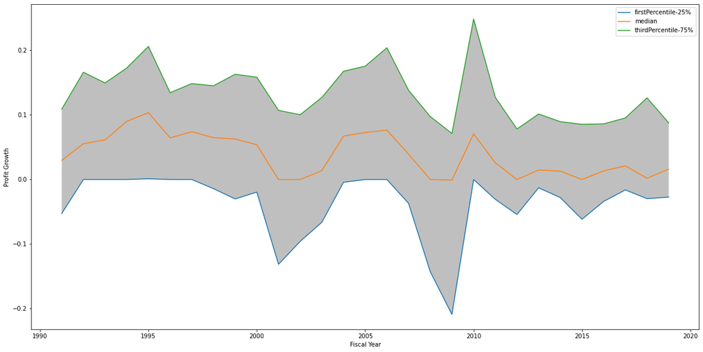

```python
plt.figure(figsize=(20,10))
#plot first percentile
yCol = 'firstPercentile'
sns.lineplot(x = "fyear", y = yCol, data = dfCompuAnnualProfit_FirstPercentile.iloc[2:-1],
            label = yCol + '-25%')
#plot median
yCol = 'median'
sns.lineplot(x = "fyear", y = yCol, data = dfCompuAnnualProfit_Median.iloc[2:-1],
            label = yCol)
#plot third percentile
yCol = 'thirdPercentile'
sns.lineplot(x = "fyear", y = yCol, data = dfCompuAnnualProfit_ThirdPercentile.iloc[2:-1],
            label = yCol + '-75%')
#shaded grey area
plt.fill_between(x = dfCompuAnnualProfit_FirstPercentile.iloc[2:-1]['fyear'].array,
                 y1 = dfCompuAnnualProfit_FirstPercentile.iloc[2:-1]['firstPercentile'].array,
                y2 = dfCompuAnnualProfit_ThirdPercentile.iloc[2:-1]['thirdPercentile'].array,
                interpolate = True,
                facecolor = 'grey',
                alpha = 0.5)
plt.xlabel("Fiscal Year")
plt.ylabel("Profit Growth")
plt.legend()
```

Given our knowledge of past events, does the chart look reasonable?

It looks reasonable as top 25% companies outperform the rest consistently over time. When there is a downturn in fiscal year, top 25% companies do not suffer huge deficit in profit growth like the rest and there is an upside in fiscal year, they perform significantly better.

### Credit Conditions and Firm-Level Profits

#### (a) Start by loading in credspread.xlsx

```python
dfCredSpread.head()
```

|  | Month | Year | BAA | AAA | CredSpread | AvgCredSpread |
| --- | --- | --- | --- | --- | --- | --- |
| 0 | 1 | 1986 | 11.37 | 10.05 | 1.32 | NaN |
| 1 | 2 | 1986 | 10.62 | 9.67 | 0.95 | NaN |
| 2 | 3 | 1986 | 10.31 | 9.00 | 1.31 | NaN |
| 3 | 4 | 1986 | 10.16 | 8.79 | 1.37 | NaN |
| 4 | 5 | 1986 | 10.41 | 9.09 | 1.32 | NaN |

#### (b) Using the Compustat data frame from 1(c), pertaining to the largest firms, create columns for “Month” and “Year” using the command df name["datadate"].dt.month and ....dt.year.

```python
dfCompuAnnualProfit['Month'] = dfCompuAnnualProfit['datadate'].dt.month
dfCompuAnnualProfit['Year'] = dfCompuAnnualProfit['datadate'].dt.year
```

#### Now merge this data frame with the one in part (a) above, using the appropriate columns.

```python
dfMerge = dfCompuAnnualProfit.merge(dfCredSpread, on = ["Month", "Year"],
                                    how = 'left')
dfMerge.head()
```

|  | conm | cusip6 | fyear | ebitda | datadate | ebitda_PreviousYear | growthPerYear | Month | Year | BAA | AAA | CredSpread | AvgCredSpread |
| --- | --- | --- | --- | --- | --- | --- | --- | --- | --- | --- | --- | --- | --- |
| 0 | AFLAC INC | 001055 | 1990 | NaN | 1990-12-31 | NaN | NaN | 12 | 1990 | 10.43 | 9.05 | 1.38 | 1.076667 |
| 1 | AFLAC INC | 001055 | 1991 | NaN | 1991-12-31 | NaN | NaN | 12 | 1991 | 9.10 | 8.31 | 0.79 | 0.967500 |
| 2 | AFLAC INC | 001055 | 1992 | NaN | 1992-12-31 | NaN | NaN | 12 | 1992 | 8.76 | 7.98 | 0.78 | 0.834167 |
| 3 | AFLAC INC | 001055 | 1993 | NaN | 1993-12-31 | NaN | NaN | 12 | 1993 | 7.77 | 6.93 | 0.84 | 0.686667 |
| 4 | AFLAC INC | 001055 | 1994 | NaN | 1994-12-31 | NaN | NaN | 12 | 1994 | 9.14 | 8.46 | 0.68 | 0.699167 |

#### (c) Our merged dataset now includes data on (i) firm-level profit growth and (ii) average credit spreads. Run the following regression and display its results:

∆Profitit =β0 +β1CSt +εit

```python
#impute growth per year with 0
dfMerge['growthPerYear'] = dfMerge['growthPerYear'].fillna(0)

#chop off observations that have profit growth in the top and bottom 1%.
growthList = dfMerge['growthPerYear'].array
bottom = np.percentile(growthList, 1)
top = np.percentile(growthList, 99)

dfMerge_Filter = dfMerge[(dfMerge['growthPerYear'] > bottom) & (dfMerge['growthPerYear'] < top)].copy()
```

```python
#linear regression
x = dfMerge_Filter['AvgCredSpread'].values.reshape(-1, 1)
y = dfMerge_Filter['growthPerYear'].values
LR = LinearRegression().fit(x, y)

#get intercept and coefficient
coeff = LR.coef_[0]
intercept = LR.intercept_
```

```python
delta = '\u0394'
def get_sub(x):
    normal = "ABCDEFGHIJKLMNOPQRSTUVWXYZabcdefghijklmnopqrstuvwxyz0123456789+-=()"
    sub_s = "ₐ₈CDₑբGₕᵢⱼₖₗₘₙₒₚQᵣₛₜᵤᵥwₓᵧZₐ♭꜀ᑯₑբ₉ₕᵢⱼₖₗₘₙₒₚ૧ᵣₛₜᵤᵥwₓᵧ₂₀₁₂₃₄₅₆₇₈₉₊₋₌₍₎"
    res = x.maketrans(''.join(normal), ''.join(sub_s))
    return x.translate(res)
print(f"{delta}Profit{get_sub('it')} = {intercept} + {coeff} CS{get_sub('t')}")
```

```
ΔProfitᵢₜ = 0.15123494779044008 + -0.10631181384785109 CSₜ
```

#### If credit spreads increase 1%, what on average, happens to a firm’s profit growth that year?

```python
dfMerge_Filter['growthPerYear_2'] = intercept + coeff*(dfMerge_Filter['AvgCredSpread'] + 0.01)
```

```python
print(f"If credit spreads increase 1%, average of a firm's profit growth that year: {dfMerge_Filter['growthPerYear_2'].mean()}")
```

```
If credit spreads increase 1%, average of a firm's profit growth that year: -0.05376224068750739
```